# European Youth Unemployment Analysis

Youth Unemployment and Gender Differences in Five Countries, 2015–2025

Author

Hamit Kaan Parlak

# 1 Introduction

Youth unemployment rates are different across countries. This report compares rates in Germany, Spain, Italy, Poland, and Turkey from 2015 to 2025. It also looks at the gap between young women and men.

The five countries provide a manageable comparison of different unemployment levels. The aim is to describe the patterns in the data, not to explain their causes.

# 2 Data and Method

The data comes from Eurostat’s annual unemployment dataset (`une_rt_a`). It covers people aged 15–24. The unemployment rate is the percentage of unemployed people in the labour force of the same age and gender group; it is not the percentage of all young people.

There are 165 country-year-gender records: 5 countries, 11 years, and 3 gender categories (female, male, total). The code checks missing values, duplicate records, and invalid percentages. Annual rates are compared using descriptive statistics. The period averages give equal weight to each year.

The gender gap is calculated as **female rate minus male rate**, in percentage points. Positive values indicate higher unemployment among women. No causal analysis or statistical hypothesis testing was performed.

# 3 Unemployment Rates by Country

The table shows the mean, standard deviation, minimum, maximum, and change from 2015 to 2025 for each country. All values are percentages, except the change, which is in percentage points (pp).

Annual youth unemployment rates: summary for 2015–2025

| Country | Mean (%) | SD | Min (%) | Max (%) | 2015 (%) | 2025 (%) | Change (pp) |
| --- | --- | --- | --- | --- | --- | --- | --- |
| Spain | 34.65 | 7.33 | 24.9 | 48.3 | 48.3 | 24.9 | -23.4 |
| Italy | 29.16 | 6.78 | 20.3 | 40.3 | 40.3 | 20.6 | -19.7 |
| Turkey | 20.05 | 3.22 | 15.4 | 25.2 | 18.5 | 15.4 | -3.1 |
| Poland | 13.01 | 3.49 | 9.7 | 21.0 | 21.0 | 12.2 | -8.8 |
| Germany | 6.87 | 0.69 | 5.9 | 7.9 | 7.7 | 7.1 | -0.6 |

Spain and Italy had the largest falls in youth unemployment between the first and last years: 23.4 and 19.7 percentage points. Germany had the lowest average rate and the smallest standard deviation in this group.

## 3.1 Trends over time

The graph shows how unemployment rates changed year by year, including increases that are not visible when only 2015 and 2025 are compared.

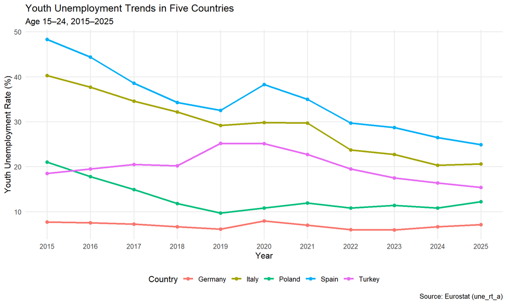

# 4 Gender Differences

Women’s and men’s rates are compared using the average annual gender gap for each country.

Average annual unemployment rates by gender, 2015–2025

| Country | Female (%) | Male (%) | Gender gap (pp) |
| --- | --- | --- | --- |
| Turkey | 25.33 | 17.15 | 8.17 |
| Italy | 31.43 | 27.66 | 3.76 |
| Spain | 35.12 | 34.26 | 0.85 |
| Poland | 13.33 | 12.76 | 0.56 |
| Germany | 6.13 | 7.50 | -1.37 |

Turkey had the largest average female–male gap among these countries (8.17 percentage points). In Germany, the average gap was negative (−1.37), meaning that the men’s rate was higher.

## 4.1 Gender gaps over time

The dashed line marks zero: above it, women’s unemployment is higher; below it, men’s unemployment is higher.

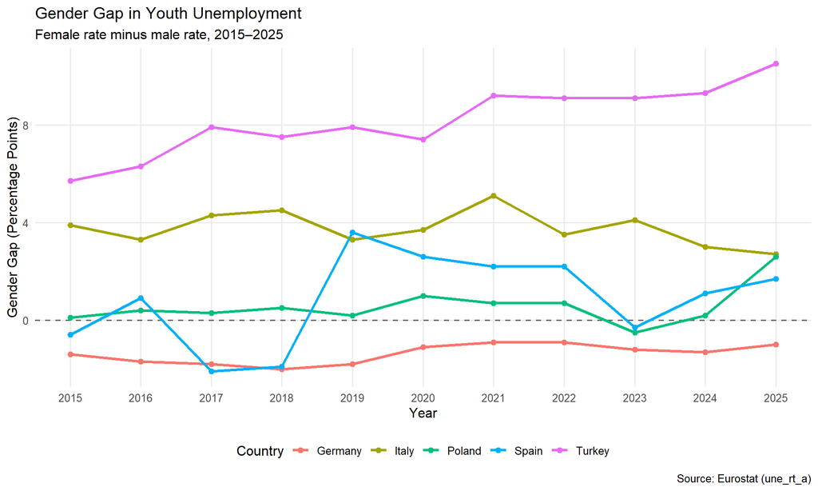

## 4.2 Change between 2015 and 2025

Change in female–male unemployment gaps

| Country | 2015 gap (pp) | 2025 gap (pp) | Change (pp) |
| --- | --- | --- | --- |
| Turkey | 5.7 | 10.5 | 4.8 |
| Poland | 0.1 | 2.6 | 2.5 |
| Spain | -0.6 | 1.7 | 2.3 |
| Germany | -1.4 | -1.0 | 0.4 |
| Italy | 3.9 | 2.7 | -1.2 |

In Turkey, the gap increased from 5.7 to 10.5 percentage points. Over the same period, the overall youth unemployment rate fell from 18.5% to 15.4%. Italy’s gap became smaller, falling by 1.2 percentage points.

# 5 Discussion

The largest decreases in overall youth unemployment were observed in Spain and Italy. However, overall rates do not tell the full story. Turkey is a useful example: its total rate fell, but the difference between young women’s and men’s rates became larger.

These patterns show why it is helpful to look at gender-specific rates as well as total unemployment. The data describes what happened, but does not show why it happened. Labour force participation and education could be useful topics for further analysis.

# 6 Limitations and Data Quality

This is a descriptive study of five countries, not a study of all European countries. The period averages are simple averages of yearly rates. They are not population-weighted rates for the entire period.

Eurostat’s data flags also matter. Some records are marked `b` (break in time series), while others are marked `d` (definition differs). Such flags may affect comparisons between years. The analysis keeps these values but notes their limitations. The exact reasons for the flags need to be checked in the relevant Eurostat metadata.

Eurostat quality flags in the selected country-year records

| Country | Year | Flag | Meaning |
| --- | --- | --- | --- |
| Germany | 2020 | b | Break in time series |
| Italy | 2018 | b | Break in time series |
| Poland | 2019 | b | Break in time series |
| Spain | 2021 | d | Definition differs |
| Spain | 2022 | d | Definition differs |
| Spain | 2023 | d | Definition differs |
| Spain | 2024 | d | Definition differs |
| Spain | 2025 | d | Definition differs |
| Turkey | 2021 | b | Break in time series |

Germany (2020), Italy (2018), Poland (2019), and Turkey (2021) have break flags. Spain’s observations for 2021–2025 carry definition-difference flags. This makes some long-term comparisons less certain.

# 7 Conclusion

All five countries had lower overall youth unemployment rates in 2025 than in 2015. Spain and Italy recorded the largest decreases, while Germany had the lowest average rate. Turkey’s unemployment gender gap increased even as its total rate fell.

Comparing overall rates with gender-specific data gives a clearer picture of unemployment trends. Future work could examine labour force participation to provide more context.

# 8 References

1. Eurostat. *Unemployment by sex and age – annual data (`une_rt_a`).* https://doi.org/10.2908/une_rt_a
2. Eurostat. *Employment and unemployment (Labour Force Survey): Information on data.* https://ec.europa.eu/eurostat/en/web/lfs/information-data

**Data accessed:** 8 November 2026. **Software:** R and Quarto.